# Comparing means from multiple groups of data

*Acknowledgements: I would really like to thank Alboukadel Kassambara for his excellent rstatix package and for the great tutorial https://www.datanovia.com/en/courses/comparing-multiple-means-in-r/*

# Part One: Parametric tests without repeated measures

Probably you are familiar with the t-test for comparing the mean of two groups. Here we discuss what to do when you want to compare the mean of multiple groups. Typically this will have two steps:

1. an omnibus test e.g. a one-way ANOVA to see if you can reject the hypothesis that the groups are the same
2. a post-hoc test where you adjust for multiple comparisons and identify which groups are different.

#### Datasets used in this tutorial

```r
library(tidyverse)
set.seed(5)
datapoints <- 30
df <- tibble(
  temperature = rep(c(15,20,25,30),each = datapoints),
  activity = c(rnorm(datapoints, mean = 5, sd = 2),
               rnorm(datapoints, mean = 5.5, sd = 2),
               rnorm(datapoints, mean = 11, sd = 2),
               rnorm(datapoints, mean = 9, sd = 2))
)
df$temperature <- as.factor(df$temperature)

set.seed(5)
dataset_treatment <- tibble(
  treatment = rep(c('control','compoundA','compoundB','compundC'),each = datapoints),
  activity = c(rnorm(datapoints, mean = 5, sd = 2),
               rnorm(datapoints, mean = 5.5, sd = 2),
               rnorm(datapoints, mean = 11, sd = 2),
               rnorm(datapoints, mean = 9, sd = 2))
)
dataset_treatment$treatment <- as.factor(dataset_treatment$treatment)
```

## One-way ANOVA and Welch’s ANOVA

### Summary checklist:

1. Repeated Measures? YES- use something else
2. Data approximately normally distributed?
   - Check with Q-Q plot and/or Shapiro-Wilk test
   - If not: use a *non-parametric test*
3. Variance of the data in each group approximately equal?
   - If not: use *Welch’s ANOVA*
4. Now conduct the One-way ANOVA
5. Can you reject the hypothesis that all groups have equal means? If so carry on to a post-hoc test to find out which groups are different:
   - Do you want to compare all the groups with each other? Use the *Tukey* test.
   - Do you want to compare multiple treatment groups with one control group? Use the *Dunnett* test.

However if you decide to use Welch’s ANOVA given unequal variance between groups:

4. Conduct Welch’s ANOVA
5. Use appropriate post-hoc tests

### Assumptions of one-way ANOVA:

1. independent observations - this is not for “repeated measures”
2. data for each group should be approximately normally distributed
3. variance of the data for each group should be equal.

#### Test for normality:

1. Q-Q plot should be roughly linear

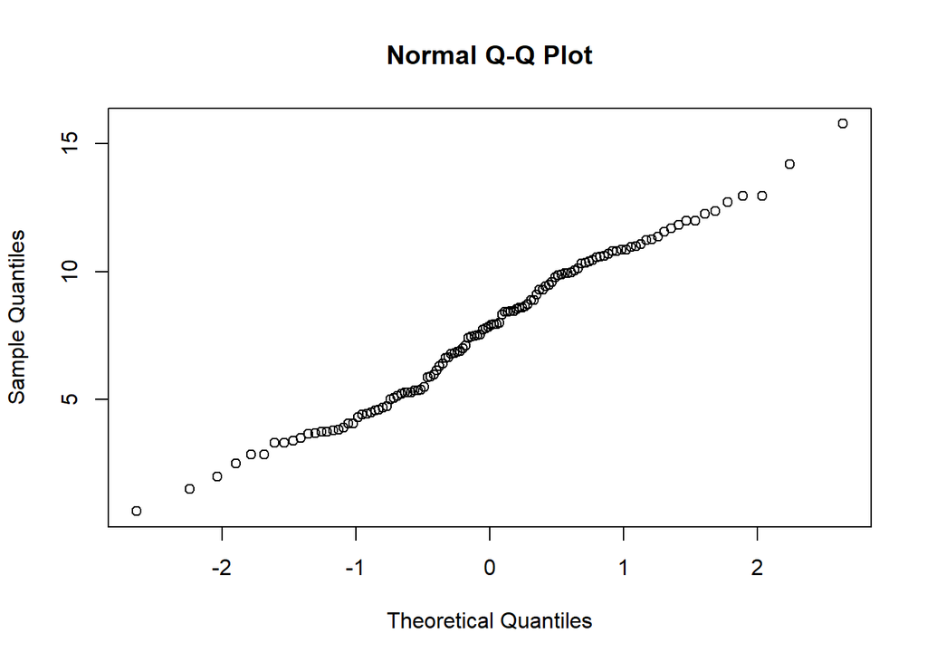

```r
qqnorm(df$activity)
```

2. Shapiro-Wilk test of normality for all the data grouped together (however for very large datasets even small deviations from normality may be significant in this test)

```r
library(rstatix)
model  <- lm(activity ~ temperature, data = df)
shapiro_test(residuals(model))
```

| variable | statistic | p.value |
| --- | --- | --- |
| residuals(model) | 0.9899149 | 0.526778 |

As the P-value is > 0.05 cannot reject the hypothesis that the data is normally distributed.

3. If you have a decent number of points for each group, you can test each group separately for normality:

```r
df %>%
  group_by(temperature) %>%
  shapiro_test(activity)
```

| temperature | variable | statistic | p |
| --- | --- | --- | --- |
| 15 | activity | 0.9508385 | 0.1780249 |
| 20 | activity | 0.9797036 | 0.8176172 |
| 25 | activity | 0.9675029 | 0.4733039 |
| 30 | activity | 0.9811840 | 0.8560926 |

or plot the Q-Q plot for each group

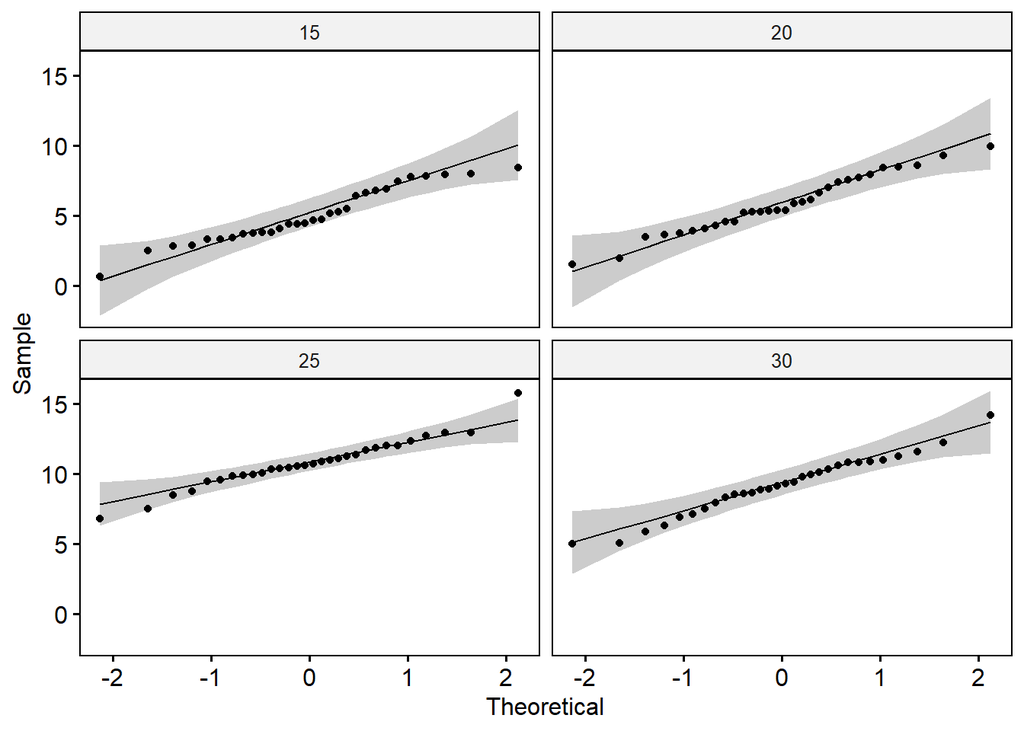

```r
library(ggpubr)
ggqqplot(df, "activity", facet.by="temperature")
```

#### Check that the variance is approximately the same for each group

Inspect with a boxplot:

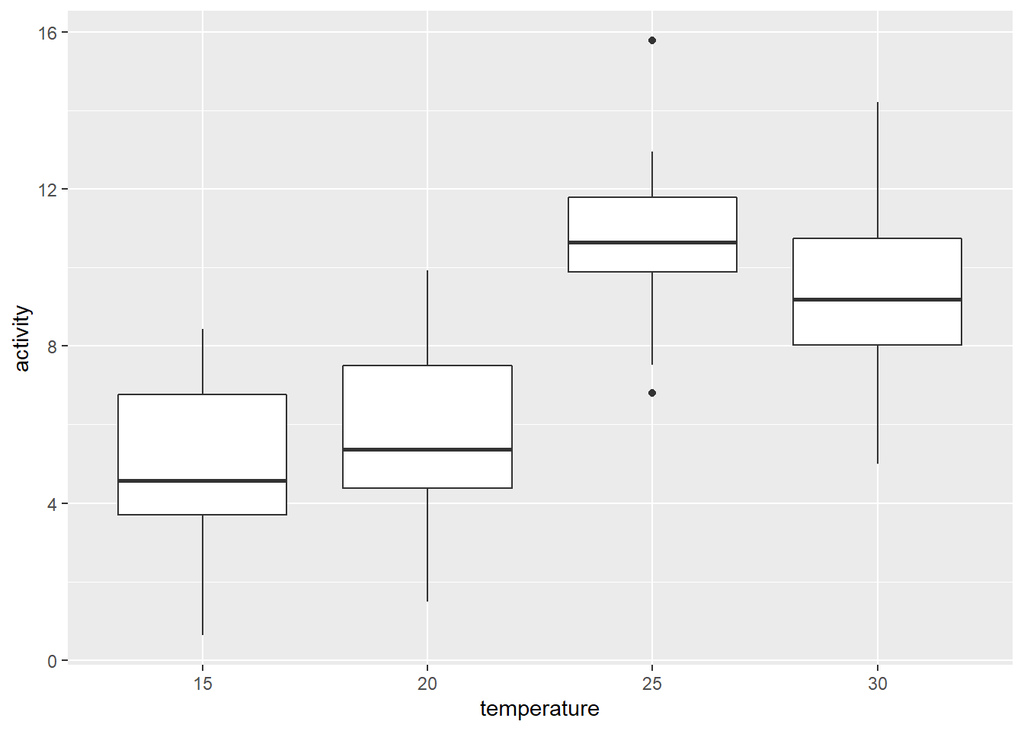

```r
ggplot(df, aes(x=temperature, y=activity)) +
  geom_boxplot()
```

Residuals plot:

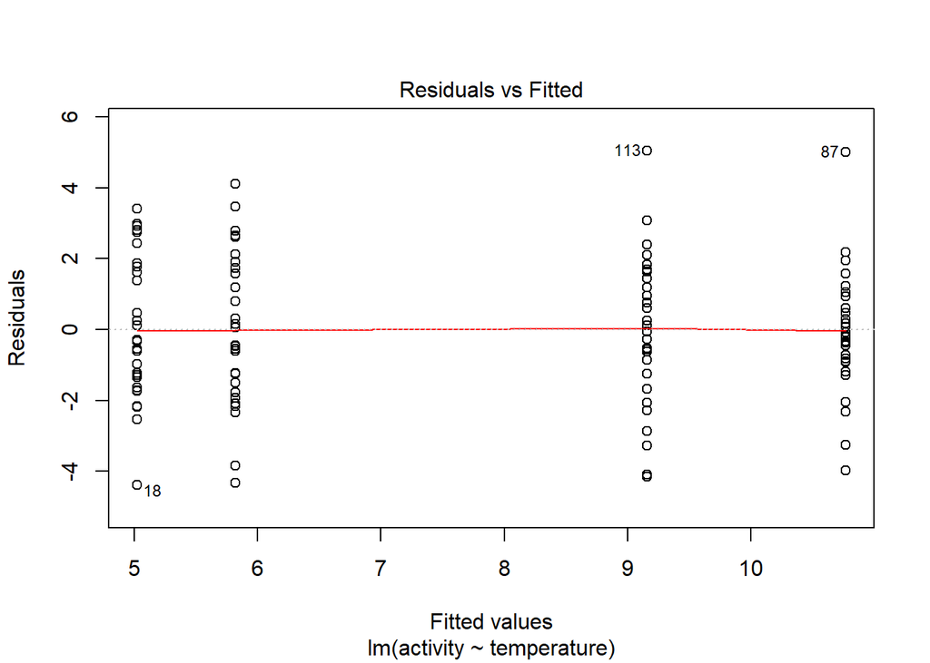

```r
plot(model,1)
```

Or Levene’s test (more robust to departures from normality than the Bartlett’s test). Read more about this here: https://uc-r.github.io/assumptions_homogeneity#levene

```r
df %>% levene_test(activity ~ temperature)
```

| df1 | df2 | statistic | p |
| --- | --- | --- | --- |
| 3 | 116 | 0.7021883 | 0.5525971 |

Can’t reject the hypothesis that the variance of each group is the same.

## Conducting the One-Way ANOVA

remember is it dependent variable ~ independent variable

```r
anova.results <- df %>% anova_test(activity ~ temperature)
anova.results
```

|  | Effect | DFn | DFd | F | p | p<.05 | ges |
| --- | --- | --- | --- | --- | --- | --- | --- |
| 1 | temperature | 3 | 116 | 55.913 | 1.97e-22 | * | 0.591 |

P < 0.05 therefore we reject the null hypothesis that all groups are the same. How to report this in a paper?

```r
paste0('[F(', anova.results$DFn,',',anova.results$DFd,') = ',
       anova.results$F, ', p = ',anova.results$p,']')
```

```
## [1] "[F(3,116) = 55.913, p = 1.97e-22]"
```

So write something like: A one-way ANOVA found that there was a significant effect of temperature on activity then add from above [F(n,n=xxx, p = xxx)]

## Post-hoc test after one-way ANOVA

You need to use a post-hoc test that takes account of the fact that you are making multiple comparisons, you can’t just do several t-tests.

### For the situation where you want to compare each group with the others

Here you use the Tukey HSD test:

```r
tukey_comparisons <- df %>% tukey_hsd(activity ~ temperature)
tukey_comparisons
```

|  | term | group1 | group2 | estimate | conf.low | conf.high | p.adj | p.adj.signif |
| --- | --- | --- | --- | --- | --- | --- | --- | --- |
| 1 | temperature | 15 | 20 | 0.7948457 | -0.5475198 | 2.1372112 | 4.15e-01 | ns |
| 2 | temperature | 15 | 25 | 5.7438405 | 4.4014750 | 7.0862059 | 2.08e-14 | **** |
| 3 | temperature | 15 | 30 | 4.1357503 | 2.7933848 | 5.4781157 | 5.37e-12 | **** |
| 4 | temperature | 20 | 25 | 4.9489948 | 3.6066293 | 6.2913602 | 4.14e-14 | **** |
| 5 | temperature | 20 | 30 | 3.3409046 | 1.9985391 | 4.6832700 | 1.34e-08 | **** |
| 6 | temperature | 25 | 30 | -1.6080902 | -2.9504557 | -0.2657247 | 1.20e-02 | * |

### For the situation where you want to compare one control group with multiple treatments

```r
anova.results <- dataset_treatment %>% anova_test(activity ~ treatment)
anova.results
```

|  | Effect | DFn | DFd | F | p | p<.05 | ges |
| --- | --- | --- | --- | --- | --- | --- | --- |
| 1 | treatment | 3 | 116 | 55.913 | 1.97e-22 | * | 0.591 |